# Project: Systemic And Banking Crisis.

### **Title**: Test the correlation of some variables with some.

## Table of Contents:

- Introduction
- Conclusions

## Introduction

- **-Banking_Crisis**: Banking problems can often be traced to a decrease the value of banks' assets:
  > - A) due to a collapse in real estate prices or When the bank asset values decrease substantially.
  > - B) if a government stops paying its obligations, this can trigger a sharp decline in value of bonds.
- **-Systemic_Crisis**: When many banks in a country are in serious solvency or liquidity problems at the same time—either:
  > - A) because there are all hits by the same outside shock.
  > - B) or because failure in one bank or a group of banks spreads to other banks in the system.
- **-Gold_Standard**: The Country have crisis in Gold Standard.
- **-Level_Country**: The description of the country whether it's Developing or Developed.

## **Research Questiones**:-

Research Question 1 : Is there a relationship between Gold Standard and Systemic Crises , and what is the strength of this relationship?

Research Question 2 : Is there a relationship between Gold Standard and Banking Crises , and what is the strength of this relationship?

Research Question 3 : Is there a relationship between Level Country and Systemic Crises , and what is the strength of this relationship?

Research Question 3 : Is there a relationship between Level Country and Banking Crises , and what is the strength of this relationship?

### Gold Standard ,Systemic Crisis

```
Gold_Standard           0         1       All
Systemic_Crisis
0                0.818329  0.119533  0.937862
1                0.053460  0.008679  0.062138
All              0.871789  0.128211  1.000000
```

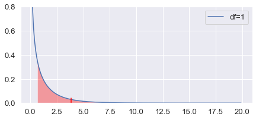

```
H0: Systemic_Crisis,Gold_Standard >>>Independent
H1: Systemic_Crisis,Gold_Standard >>>Dependent


Chi_SqV=0.5672158940950885,
P_Value=0.4513673717004746,
DF=1


Not reject Null Hypothesis
(H0): Systemic_Crisis,Gold_Standard >>>Independent


Relationship=60.160270758337475%
```

```python
Chi_Sq_indep("Systemic_Crisis","Gold_Standard")
```

## Gold Standard, Banking Crisis

```
Gold_Standard          0         1       All
Banking_Crisis
0               0.792525  0.116293  0.908817
1               0.079264  0.011919  0.091183
All             0.871789  0.128211  1.000000
```

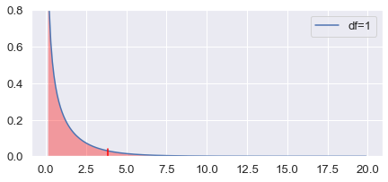

```
H0: Banking_Crisis,Gold_Standard >>>Independent
H1: Banking_Crisis,Gold_Standard >>>Dependent


Chi_SqV=0.026984079229680363,
P_Value=0.8695199239993506,
DF=1


Not reject Null Hypothesis
(H0): Banking_Crisis,Gold_Standard >>>Independent


Relationship=16.209586867566607%
```

```python
Chi_Sq_indep("Banking_Crisis","Gold_Standard")
```

### Level Country ,Systemic Crisis

```
Level_Country    Developed regions  Developing regions       All
Systemic_Crisis
0                         0.443647            0.494214  0.937862
1                         0.029160            0.032978  0.062138
All                       0.472807            0.527193  1.000000
```

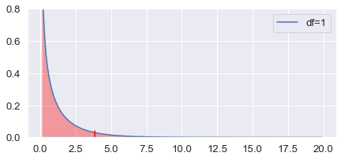

```
H0: Systemic_Crisis,Level_Country >>>Independent
H1: Systemic_Crisis,Level_Country >>>Dependent


Chi_SqV=0.015556898277722131,
P_Value=0.9007394473428232,
DF=1


Not reject Null Hypothesis
(H0): Systemic_Crisis,Level_Country >>>Independent


Relationship=12.376828573520719%
```

```python
Chi_Sq_indep("Systemic_Crisis","Level_Country")
```

```
Level_Country   Developed regions  Developing regions       All
Banking_Crisis
0                        0.423745            0.485073  0.908817
1                        0.049063            0.042120  0.091183
All                      0.472807            0.527193  1.000000
```

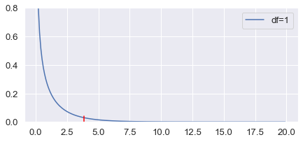

```
H0: Banking_Crisis,Level_Country >>>Independent
H1: Banking_Crisis,Level_Country >>>Dependent


Chi_SqV=14.52965508683507,
P_Value=0.00013797050536313657,
DF=1


reject Null Hypothesis (H0),And favor Alternative
(H1): Banking_Crisis,Level_Country >>>Dependent


Relationship=96.72678375428329%
```

```python
Chi_Sq_indep("Banking_Crisis","Level_Country")
```

### Conclusions

#### From the information above it becomes clear that:

> - Systemic_Crisis And Gold_Standard >>>Independent > **Relationship=60%**.
> - Banking_Crisis And Gold_Standard >>>Independent > **Relationship=16%**.
> - Systemic_Crisis And Level_Country >>>Independent > **Relationship=12%**.
> - Banking_Crisis And Level_Country >>>Dependent > **Relationship=97%**.